#### INFO6250

# United States House Rent Prediction

### Team 12

Prashanti Salunkhe : 002133330 | Pratik Randad : 002133847

## • Introduction

The main goal of the research is to create a prediction model using Machine Learning to predict the rental costs of houses across the United States based on numerous variables defining the houses' attributes. This dataset contains several features that characterize the entire nature of the house and its dynamics, as well as ‘Price’ which is to be predicted.

```python
import geopandas as gpd
```

```python
import pandas as pd
import numpy as np
import matplotlib.pyplot as plt
import seaborn as sns
sns.set();
%matplotlib inline
```

## • Importing Data

```python
src_data = pd.read_csv('housing_train.csv')
```

## • Data Description

```python
src_data.head()
```

|  | id | url | region | region_url | price | type | sqfeet | beds | baths | cats_allowed | ... | wheelchair_access | electric_vehicle_charge | comes_furnished | laundry_options | parking_options | image_url | description | lat | long | state |
| --- | --- | --- | --- | --- | --- | --- | --- | --- | --- | --- | --- | --- | --- | --- | --- | --- | --- | --- | --- | --- | --- |
| 0 | 7039061606 | https://bham.craigslist.org/apa/d/birmingham-h... | birmingham | https://bham.craigslist.org | 1195 | apartment | 1908 | 3 | 2.0 | 1 | ... | 0 | 0 | 0 | laundry on site | street parking | https://images.craigslist.org/00L0L_80pNkyDeG0... | Apartments In Birmingham AL Welcome to 100 Inv... | 33.4226 | -86.7065 | al |
| 1 | 7041970863 | https://bham.craigslist.org/apa/d/birmingham-w... | birmingham | https://bham.craigslist.org | 1120 | apartment | 1319 | 3 | 2.0 | 1 | ... | 0 | 0 | 0 | laundry on site | off-street parking | https://images.craigslist.org/00707_uRrY9CsNMC... | Find Your Way to Haven Apartment Homes Come ho... | 33.3755 | -86.8045 | al |
| 2 | 7041966914 | https://bham.craigslist.org/apa/d/birmingham-g... | birmingham | https://bham.craigslist.org | 825 | apartment | 1133 | 1 | 1.5 | 1 | ... | 0 | 0 | 0 | laundry on site | street parking | https://images.craigslist.org/00h0h_b7Bdj1NLBi... | Apartments In Birmingham AL Welcome to 100 Inv... | 33.4226 | -86.7065 | al |
| 3 | 7041966936 | https://bham.craigslist.org/apa/d/birmingham-f... | birmingham | https://bham.craigslist.org | 800 | apartment | 927 | 1 | 1.0 | 1 | ... | 0 | 0 | 0 | laundry on site | street parking | https://images.craigslist.org/00808_6ghZ8tSRQs... | Apartments In Birmingham AL Welcome to 100 Inv... | 33.4226 | -86.7065 | al |
| 4 | 7041966888 | https://bham.craigslist.org/apa/d/birmingham-2... | birmingham | https://bham.craigslist.org | 785 | apartment | 1047 | 2 | 1.0 | 1 | ... | 0 | 0 | 0 | laundry on site | street parking | https://images.craigslist.org/00y0y_21c0FOvUXm... | Apartments In Birmingham AL Welcome to 100 Inv... | 33.4226 | -86.7065 | al |

5 rows × 22 columns

```python
src_data.tail()
```

|  | id | url | region | region_url | price | type | sqfeet | beds | baths | cats_allowed | ... | wheelchair_access | electric_vehicle_charge | comes_furnished | laundry_options | parking_options | image_url | description | lat | long | state |
| --- | --- | --- | --- | --- | --- | --- | --- | --- | --- | --- | --- | --- | --- | --- | --- | --- | --- | --- | --- | --- | --- |
| 265185 | 7050851033 | https://columbus.craigslist.org/apa/d/columbus... | columbus | https://columbus.craigslist.org | 0 | apartment | 1061 | 2 | 2.0 | 1 | ... | 0 | 0 | 0 | w/d in unit | detached garage | https://images.craigslist.org/00m0m_8wP9hX96TZ... | â BERKLEY HOUSE â Voted #1 BEST Communit... | 40.0495 | -83.0669 | oh |
| 265186 | 7050887997 | https://columbus.craigslist.org/apa/d/grove-ci... | columbus | https://columbus.craigslist.org | 1069 | apartment | 1020 | 2 | 1.5 | 1 | ... | 0 | 0 | 0 | w/d hookups | detached garage | https://images.craigslist.org/00N0N_ioCvFNCv24... | !!!!Tour today and receive $5 Starbucks gift c... | 39.8408 | -83.0804 | oh |
| 265187 | 7044801015 | https://columbus.craigslist.org/apa/d/columbus... | columbus | https://columbus.craigslist.org | 1507 | apartment | 1660 | 2 | 1.5 | 1 | ... | 0 | 0 | 0 | NaN | NaN | https://images.craigslist.org/00j0j_5EIRWzdHCV... | The Commons at Olentangy4765 Blairfield Dr, Co... | 40.0564 | -83.0417 | oh |
| 265188 | 7050885800 | https://columbus.craigslist.org/apa/d/newark-l... | columbus | https://columbus.craigslist.org | 1001 | apartment | 1220 | 3 | 1.5 | 1 | ... | 0 | 0 | 0 | w/d hookups | off-street parking | https://images.craigslist.org/00J0J_6VSTqFJb86... | www.McMillenWoods.com www.mcmillenwoods.com ... | 40.0451 | -82.4564 | oh |
| 265189 | 7050884586 | https://columbus.craigslist.org/apa/d/columbus... | columbus | https://columbus.craigslist.org | 1164 | townhouse | 1300 | 2 | 2.5 | 1 | ... | 0 | 0 | 0 | w/d hookups | attached garage | https://images.craigslist.org/00w0w_h1L3gxb8rG... | Park Club apartments is offering some of the B... | NaN | NaN | NaN |

5 rows × 22 columns

```python
src_data.info()
```

```
<class 'pandas.core.frame.DataFrame'>
RangeIndex: 265190 entries, 0 to 265189
Data columns (total 22 columns):
 #   Column                   Non-Null Count   Dtype
---  ------                   --------------   -----
 0   id                       265190 non-null  int64
 1   url                      265190 non-null  object
 2   region                   265190 non-null  object
 3   region_url               265190 non-null  object
 4   price                    265190 non-null  int64
 5   type                     265190 non-null  object
 6   sqfeet                   265190 non-null  int64
 7   beds                     265190 non-null  int64
 8   baths                    265190 non-null  float64
 9   cats_allowed             265190 non-null  int64
 10  dogs_allowed             265190 non-null  int64
 11  smoking_allowed          265190 non-null  int64
 12  wheelchair_access        265190 non-null  int64
 13  electric_vehicle_charge  265190 non-null  int64
 14  comes_furnished          265190 non-null  int64
 15  laundry_options          210879 non-null  object
 16  parking_options          170055 non-null  object
 17  image_url                265190 non-null  object
 18  description              265188 non-null  object
 19  lat                      263771 non-null  float64
 20  long                     263771 non-null  float64
 21  state                    265189 non-null  object
dtypes: float64(3), int64(10), object(9)
memory usage: 44.5+ MB
```

##### There are 13 numerical and 9 category features in all.

```python
src_data.describe()
```

|  | id | price | sqfeet | beds | baths | cats_allowed | dogs_allowed | smoking_allowed | wheelchair_access | electric_vehicle_charge | comes_furnished | lat | long |
| --- | --- | --- | --- | --- | --- | --- | --- | --- | --- | --- | --- | --- | --- |
| count | 2.651900e+05 | 2.651900e+05 | 2.651900e+05 | 265190.000000 | 265190.000000 | 265190.000000 | 265190.000000 | 265190.000000 | 265190.000000 | 265190.000000 | 265190.000000 | 263771.000000 | 263771.000000 |
| mean | 7.040888e+09 | 1.227285e+04 | 1.093678e+03 | 1.912414 | 1.483468 | 0.716822 | 0.696550 | 0.733896 | 0.078759 | 0.014360 | 0.048644 | 37.208855 | -92.398149 |
| std | 8.778930e+06 | 5.376352e+06 | 2.306888e+04 | 3.691900 | 0.630208 | 0.450543 | 0.459749 | 0.441920 | 0.269362 | 0.118968 | 0.215124 | 5.659648 | 17.370780 |
| min | 7.003808e+09 | 0.000000e+00 | 0.000000e+00 | 0.000000 | 0.000000 | 0.000000 | 0.000000 | 0.000000 | 0.000000 | 0.000000 | 0.000000 | -43.533300 | -163.894000 |
| 25% | 7.035963e+09 | 8.170000e+02 | 7.520000e+02 | 1.000000 | 1.000000 | 0.000000 | 0.000000 | 0.000000 | 0.000000 | 0.000000 | 0.000000 | 33.508500 | -104.704000 |
| 50% | 7.043109e+09 | 1.060000e+03 | 9.500000e+02 | 2.000000 | 1.000000 | 1.000000 | 1.000000 | 1.000000 | 0.000000 | 0.000000 | 0.000000 | 37.984900 | -86.478300 |
| 75% | 7.048362e+09 | 1.450000e+03 | 1.156000e+03 | 2.000000 | 2.000000 | 1.000000 | 1.000000 | 1.000000 | 0.000000 | 0.000000 | 0.000000 | 41.168400 | -81.284600 |
| max | 7.051263e+09 | 2.768307e+09 | 8.388607e+06 | 1100.000000 | 75.000000 | 1.000000 | 1.000000 | 1.000000 | 1.000000 | 1.000000 | 1.000000 | 102.036000 | 172.633000 |

```python
print(src_data.columns.shape)
```

```
(22,)
```

##### Our dataset has a total of 265,190 rows and 22 columns.

## • Data Cleaning

### 1.Dropping Unwanted Columns

##### We can remove the columns id, url, region url, image url, and description from our dataset because we know they aren't needed for our current situation.

```python
data = src_data.drop(columns = ['id', 'url', 'region_url', 'image_url', 'description'])
```

```python
data.head()
```

|  | region | price | type | sqfeet | beds | baths | cats_allowed | dogs_allowed | smoking_allowed | wheelchair_access | electric_vehicle_charge | comes_furnished | laundry_options | parking_options | lat | long | state |
| --- | --- | --- | --- | --- | --- | --- | --- | --- | --- | --- | --- | --- | --- | --- | --- | --- | --- |
| 0 | birmingham | 1195 | apartment | 1908 | 3 | 2.0 | 1 | 1 | 1 | 0 | 0 | 0 | laundry on site | street parking | 33.4226 | -86.7065 | al |
| 1 | birmingham | 1120 | apartment | 1319 | 3 | 2.0 | 1 | 1 | 1 | 0 | 0 | 0 | laundry on site | off-street parking | 33.3755 | -86.8045 | al |
| 2 | birmingham | 825 | apartment | 1133 | 1 | 1.5 | 1 | 1 | 1 | 0 | 0 | 0 | laundry on site | street parking | 33.4226 | -86.7065 | al |
| 3 | birmingham | 800 | apartment | 927 | 1 | 1.0 | 1 | 1 | 1 | 0 | 0 | 0 | laundry on site | street parking | 33.4226 | -86.7065 | al |
| 4 | birmingham | 785 | apartment | 1047 | 2 | 1.0 | 1 | 1 | 1 | 0 | 0 | 0 | laundry on site | street parking | 33.4226 | -86.7065 | al |

### 2.Analyzing and Filling Null Values

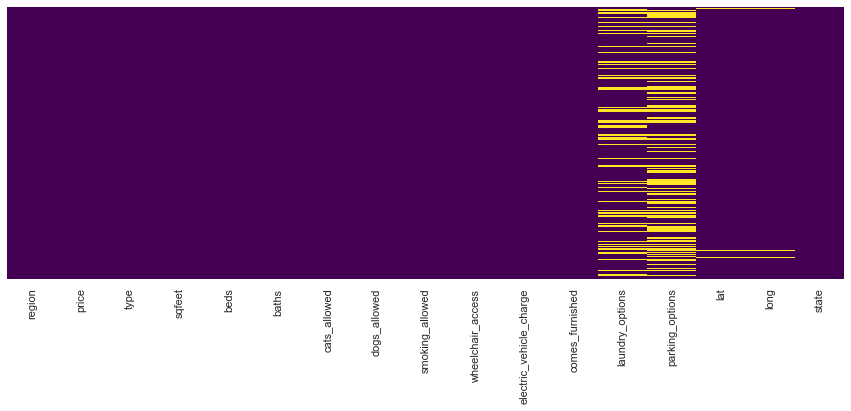

```python
plt.figure(figsize=(15,5))
sns.heatmap(data.isnull(),yticklabels=False,cmap='viridis',cbar=False)
```

```python
data.isna().sum()
```

```
region                         0
price                          0
type                           0
sqfeet                         0
beds                           0
baths                          0
cats_allowed                   0
dogs_allowed                   0
smoking_allowed                0
wheelchair_access              0
electric_vehicle_charge        0
comes_furnished                0
laundry_options            54311
parking_options            95135
lat                         1419
long                        1419
state                          1
dtype: int64
```

##### We see that the 'lat' and 'long' columns have less null values, so we eliminate them.

```python
data=data[data['lat'].notna()]
```

##### Used the most frequent values in each column to fill in the missing values in each columns, thereby eliminating null values

```python
data=data.fillna(data.mode().iloc[0])
```

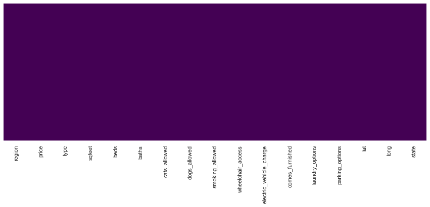

```python
plt.figure(figsize=(15,5))
sns.heatmap(data.isnull(),yticklabels=False,cmap='viridis',cbar=False)
```

## • Identifying and Handling Outliers

##### Checking outliers in each column

```python
data.columns
```

```
Index(['region', 'price', 'type', 'sqfeet', 'beds', 'baths', 'cats_allowed',
       'dogs_allowed', 'smoking_allowed', 'wheelchair_access',
       'electric_vehicle_charge', 'comes_furnished', 'laundry_options',
       'parking_options', 'lat', 'long', 'state'],
      dtype='object')
```

```python
data['type'].value_counts()
```

```
apartment          217090
house               23400
townhouse           10295
condo                4841
duplex               3436
manufactured         3004
cottage/cabin         697
loft                  510
flat                  349
in-law                144
land                    4
assisted living         1
Name: type, dtype: int64
```

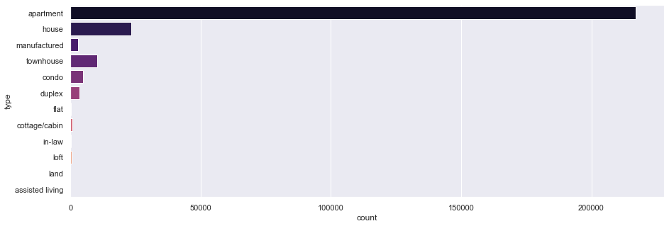

```python
plt.figure(figsize=(15,5))
sns.set_theme(style="darkgrid")
sns.countplot(y ='type',data = data,palette="magma")
```

##### Because the data on land and assisted living is so small in comparison to the rest of the data, deleting them is the greatest choice for improving accuracy.

```python
data=data[data['type']!='land']
data=data[data['type']!='assisted living']
```

```python
data['sqfeet'].value_counts()
```

```
1000    7499
900     5781
800     5447
1200    4844
1100    4706
        ...
3097       1
2316       1
2193       1
2854       1
255        1
Name: sqfeet, Length: 3033, dtype: int64
```

##### As per the data from "statista.com" the average house size in all of the United States is 3,000 square feet, so restricting the value to above 3000

```python
#checking houses with squarefeet greater than 3000
data[data.sqfeet > 3000]
```

|  | region | price | type | sqfeet | beds | baths | cats_allowed | dogs_allowed | smoking_allowed | wheelchair_access | electric_vehicle_charge | comes_furnished | laundry_options | parking_options | lat | long | state |
| --- | --- | --- | --- | --- | --- | --- | --- | --- | --- | --- | --- | --- | --- | --- | --- | --- | --- |
| 62 | birmingham | 1260 | apartment | 5201 | 3 | 2.0 | 1 | 1 | 1 | 0 | 0 | 0 | w/d in unit | off-street parking | 33.4188 | -86.7867 | al |
| 1237 | huntsville / decatur | 559 | apartment | 4980 | 0 | 1.0 | 1 | 1 | 1 | 0 | 0 | 0 | laundry on site | off-street parking | 34.7389 | -86.6249 | al |
| 1930 | huntsville / decatur | 1200 | house | 3077 | 5 | 3.5 | 1 | 1 | 1 | 0 | 0 | 0 | w/d in unit | attached garage | 33.5159 | -101.9340 | al |
| 2021 | huntsville / decatur | 5 | house | 5550 | 5 | 4.0 | 0 | 0 | 1 | 0 | 0 | 0 | w/d in unit | attached garage | 34.0408 | -84.3859 | al |
| 2035 | huntsville / decatur | 5 | house | 5550 | 5 | 4.0 | 0 | 0 | 1 | 0 | 0 | 0 | w/d in unit | attached garage | 34.0408 | -84.3859 | al |
| ... | ... | ... | ... | ... | ... | ... | ... | ... | ... | ... | ... | ... | ... | ... | ... | ... | ... |
| 263801 | cleveland | 7995 | house | 9972 | 6 | 7.0 | 0 | 0 | 1 | 0 | 0 | 0 | w/d in unit | off-street parking | 41.4826 | -81.5635 | oh |
| 263804 | cleveland | 3999 | house | 7000 | 5 | 5.0 | 0 | 0 | 1 | 0 | 0 | 0 | w/d in unit | off-street parking | 41.3895 | -82.2382 | oh |
| 263824 | cleveland | 3000 | house | 5416 | 5 | 5.5 | 0 | 0 | 1 | 0 | 0 | 0 | w/d in unit | attached garage | 41.4956 | -81.5023 | oh |
| 264198 | cleveland | 3500 | townhouse | 6000 | 2 | 2.0 | 1 | 1 | 1 | 0 | 0 | 1 | w/d in unit | off-street parking | 41.5110 | -81.6597 | oh |
| 264641 | cleveland | 2800 | house | 5200 | 6 | 3.5 | 0 | 0 | 1 | 0 | 0 | 0 | laundry in bldg | detached garage | 41.0302 | -80.7233 | oh |

976 rows × 17 columns

```python
data=data[data.sqfeet <= 3000].reset_index(drop = True)
```

```python
data['beds'].value_counts()
```

```
2       119452
1        80256
3        46404
4         7713
0         7461
5         1347
6          117
7           22
8           16
1100         2
Name: beds, dtype: int64
```

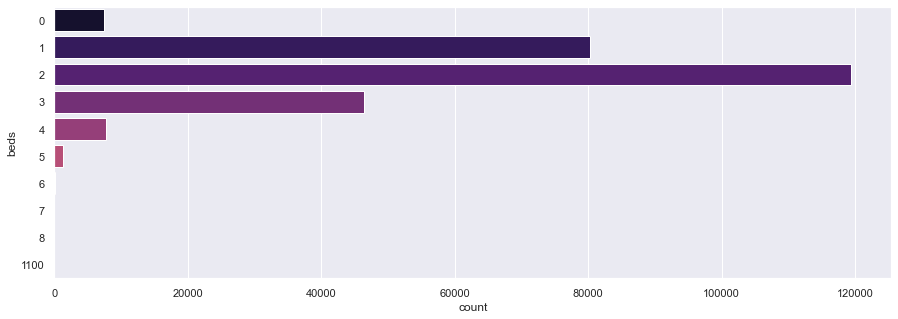

```python
plt.figure(figsize=(15,5))
sns.countplot(y ='beds',data = data,palette=sns.color_palette('magma',10))
```

##### The number of a beds cannot possibly be 1100, so we dropped it.

```python
data=data[data['beds']<1100].reset_index(drop=True)
```

```python
data['baths'].value_counts()
```

```
1.0    135652
2.0     93160
1.5     18377
2.5      7997
3.0      3944
0.0      2024
4.0       988
3.5       475
4.5        77
5.0        65
5.5        21
6.0         7
8.0         1
Name: baths, dtype: int64
```

##### Number of bathrooms definitely cannot be 0 and more than 6 are outliers so removing them.

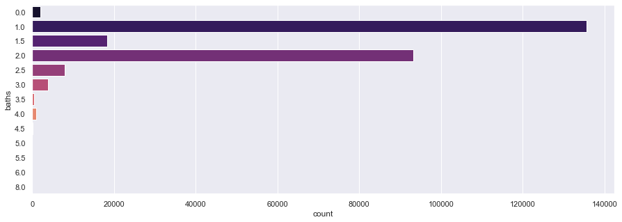

```python
plt.figure(figsize=(15,5))
sns.countplot(y ='baths',data = data,palette=sns.color_palette('magma',10))
```

```python
data=data.loc[(data['baths']>0) & (data['baths']<7)].reset_index(drop=True)
```

```python
data['cats_allowed'].value_counts()
```

```
1    187246
0     73517
Name: cats_allowed, dtype: int64
```

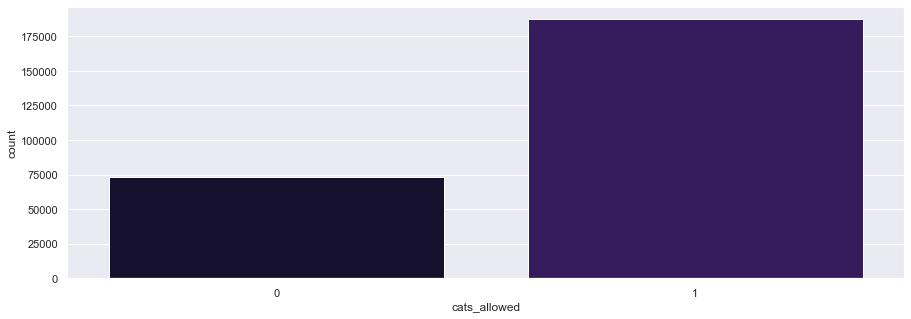

```python
plt.figure(figsize=(15,5))
sns.countplot(x ='cats_allowed',data = data,palette=sns.color_palette('magma',10))
```

```python
data['dogs_allowed'].value_counts()
```

```
1    181843
0     78920
Name: dogs_allowed, dtype: int64
```

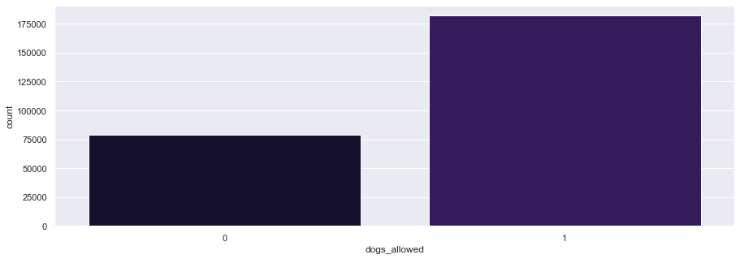

```python
plt.figure(figsize=(15,5))
sns.countplot(x ='dogs_allowed',data = data,palette=sns.color_palette('magma',10))
```

```python
data['smoking_allowed'].value_counts()
```

```
1    191381
0     69382
Name: smoking_allowed, dtype: int64
```

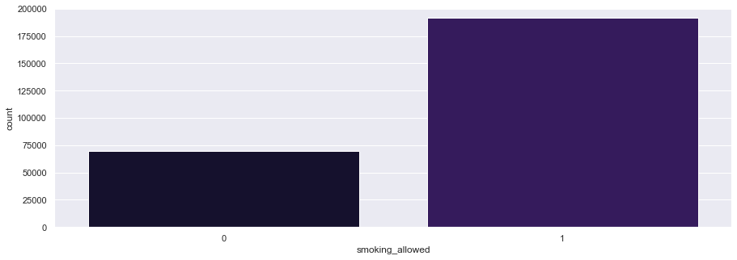

```python
plt.figure(figsize=(15,5))
sns.countplot(x ='smoking_allowed',data = data,palette=sns.color_palette('magma',10))
```

```python
data['wheelchair_access'].value_counts()
```

```
0    240057
1     20706
Name: wheelchair_access, dtype: int64
```

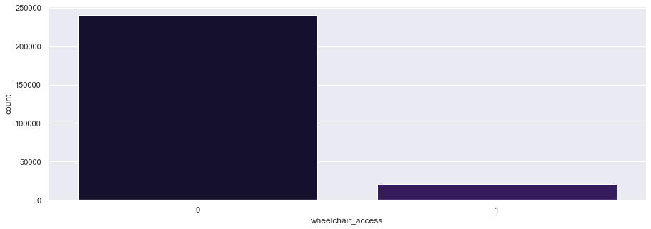

```python
plt.figure(figsize=(15,5))
sns.countplot(x ='wheelchair_access',data = data,palette=sns.color_palette('magma',10))
```

```python
data['electric_vehicle_charge'].value_counts()
```

```
0    256995
1      3768
Name: electric_vehicle_charge, dtype: int64
```

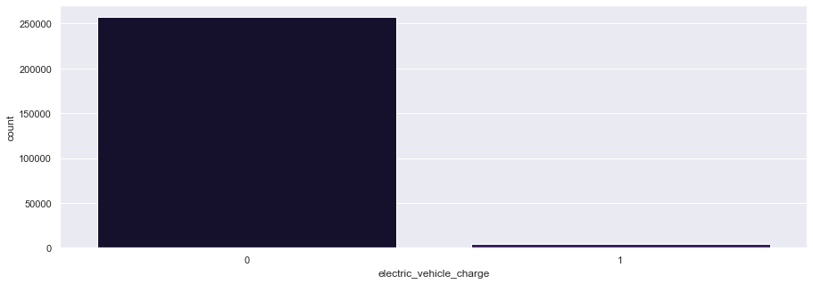

```python
plt.figure(figsize=(15,5))
sns.countplot(x ='electric_vehicle_charge',data = data,palette=sns.color_palette('magma',10))
```

```python
data['comes_furnished'].value_counts()
```

```
0    248364
1     12399
Name: comes_furnished, dtype: int64
```

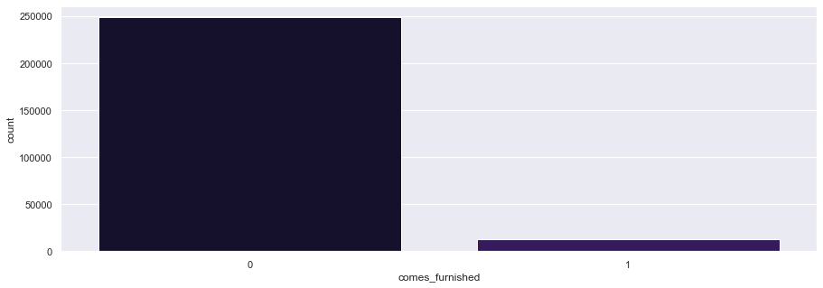

```python
plt.figure(figsize=(15,5))
sns.countplot(x ='comes_furnished',data = data,palette=sns.color_palette('magma',10))
```

```python
data['laundry_options'].value_counts()
```

```
w/d in unit           142655
w/d hookups            49366
laundry on site        38819
laundry in bldg        27422
no laundry on site      2501
Name: laundry_options, dtype: int64
```

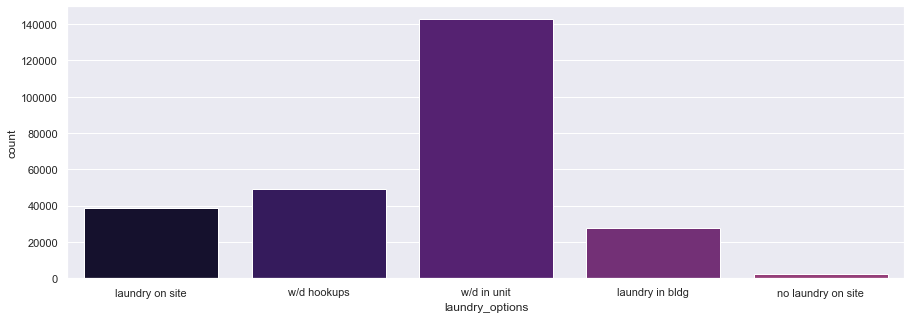

```python
plt.figure(figsize=(15,5))
sns.countplot(x ='laundry_options',data = data,palette=sns.color_palette('magma',10))
```

```python
data['parking_options'].value_counts()
```

```
off-street parking    180532
carport                28432
attached garage        26594
detached garage        12678
street parking         10456
no parking              1952
valet parking            119
Name: parking_options, dtype: int64
```

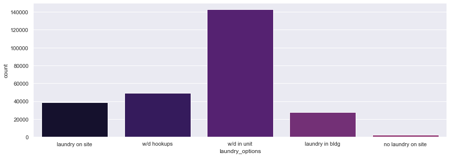

```python
plt.figure(figsize=(15,5))
sns.countplot(x ='laundry_options',data = data,palette=sns.color_palette('magma',10))
```

##### Identifying ouliers in 'Price' column

```python
data.price
```

```
0         1195
1         1120
2          825
3          800
4          785
          ...
260758     929
260759       0
260760    1069
260761    1507
260762    1001
Name: price, Length: 260763, dtype: int64
```

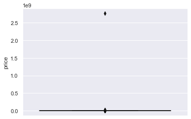

```python
sns.boxplot( y=data["price"],palette=sns.color_palette("magma",10));
plt.show()
```

```python
data.price.describe()
```

```
count    2.607630e+05
mean     1.235957e+04
std      5.421717e+06
min      0.000000e+00
25%      8.170000e+02
50%      1.059000e+03
75%      1.449000e+03
max      2.768307e+09
Name: price, dtype: float64
```

##### We can't see the plot since the prices are so disparate. Limiting the rent to a maximum of $5000

```python
data=data[data['price']<=5000].reset_index(drop=True)
```

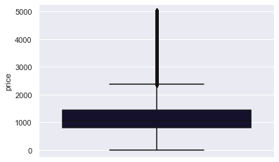

```python
sns.boxplot( y=data["price"],palette=sns.color_palette("magma",10));
plt.show()
```

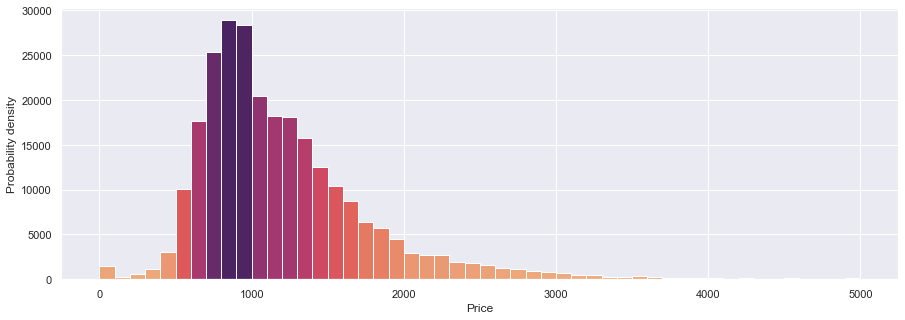

```python
plt.figure(figsize=(15,5))
bins = 50

cm = plt.cm.get_cmap('flare')
n, bins, patches = plt.hist(data.price, bins)

col = (n-n.min())/(n.max()-n.min())
for c, p in zip(col, patches):
    plt.setp(p, 'facecolor', cm(c))

plt.xlabel('Price')
plt.ylabel('Probability density')
plt.show()
```

##### Removing price greater than $4000

```python
data=data[data['price']<=4000].reset_index(drop=True)
```

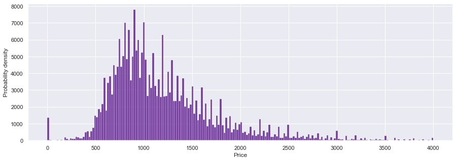

```python
plt.figure(figsize=(15,5))
sns.histplot(data, x="price", color='indigo')
plt.xlabel('Price')
plt.ylabel('Probability density')
```

# • Data Visualization

##### Visualizing type of apartments on a map

```python
import geopandas as gpd
from shapely.geometry import Point, Polygon
from geopandas import GeoDataFrame as gdf
import warnings
```

```python
viz=gpd.read_file('s_22mr22.shp')
geometry=[Point(xy) for xy in zip(data['long'], data['lat'])]
crs={'init':'epsg:4326'}
```

```python
geo_df=gpd.GeoDataFrame(data,crs=crs,geometry=geometry)
geo_df.head()
warnings.simplefilter('ignore')
```

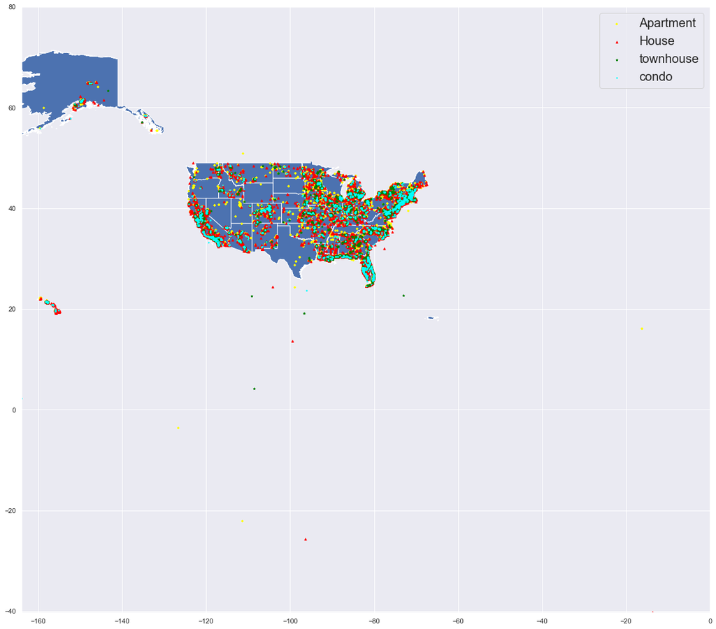

```python
fig,ax=plt.subplots(figsize=(20,20))
viz.plot(ax=ax)
geo_df[geo_df['type']=='apartment'].plot(ax=ax,markersize=10,color="yellow",marker="+",label="Apartment")
geo_df[geo_df['type']=='house'].plot(ax=ax,markersize=10,color="red",marker="^",label="House")
geo_df[geo_df['type']=='townhouse'].plot(ax=ax,markersize=10,color="green",marker="*",label="townhouse")
geo_df[geo_df['type']=='condo'].plot(ax=ax,markersize=10,color="cyan",marker=".",label="condo")
minx, miny, maxx, maxy = geo_df.total_bounds
ax.set_xlim(minx, 0)
ax.set_ylim(miny, 80)
plt.legend(prop={'size':20})
```

[output not shown]

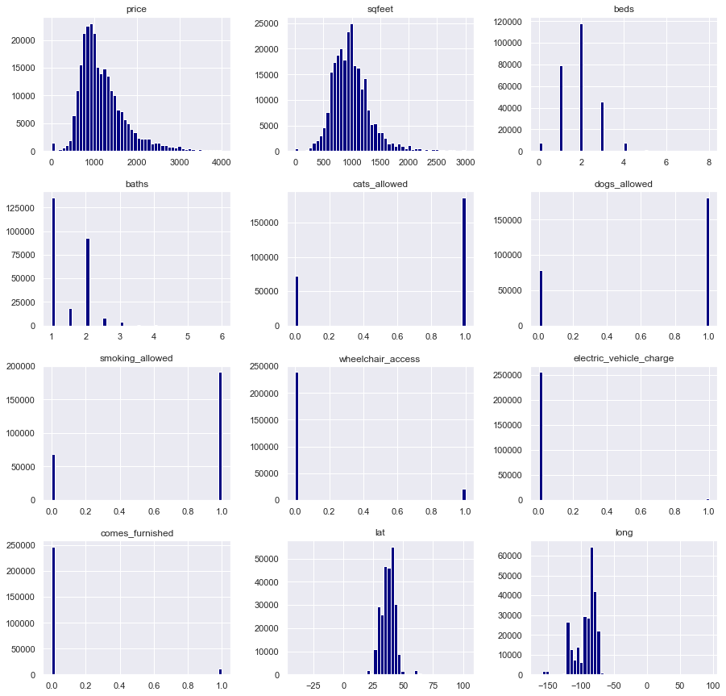

```python
data.hist(bins = 50, figsize = (15,15),color="navy")
```

##### Heatmap to visualize co-relation between columns

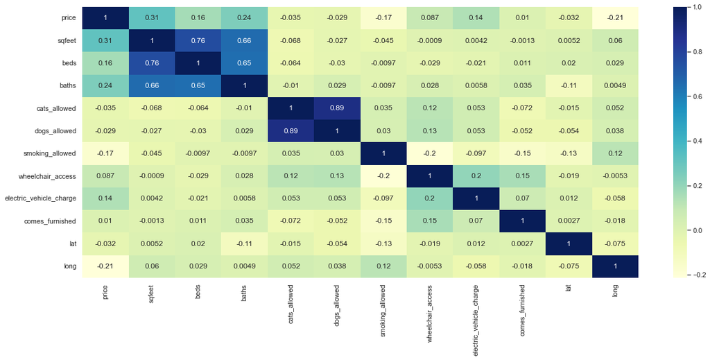

```python
corr=data.corr(method='pearson')
plt.figure(figsize=(20, 8))
sns.heatmap(corr,cmap="YlGnBu",annot=True)
```

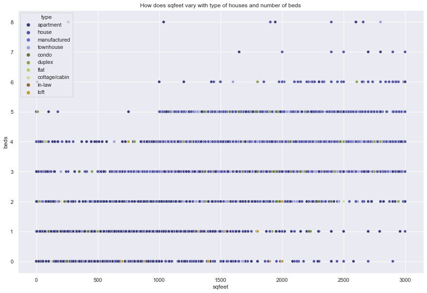

```python
plt.figure(figsize=(15,10))
plt.title('How does sqfeet vary with type of houses and number of beds')
sns.scatterplot(data=data, x="sqfeet", y="beds",hue="type",palette="tab20b")
```

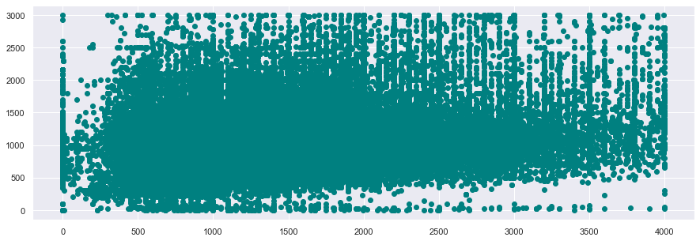

```python
plt.figure(figsize=(15,5))
plt.scatter(data.price, data.sqfeet,color="teal")
```

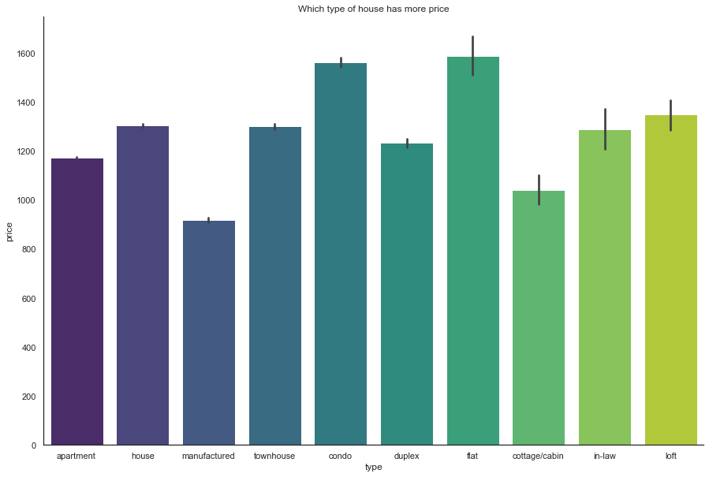

```python
sns.set_style("white")

fig, ax = plt.subplots(figsize=(15, 10))
sns.barplot(data["type"], data["price"],ax=ax,palette="viridis")
plt.title('Which type of house has more price')
sns.despine()
```

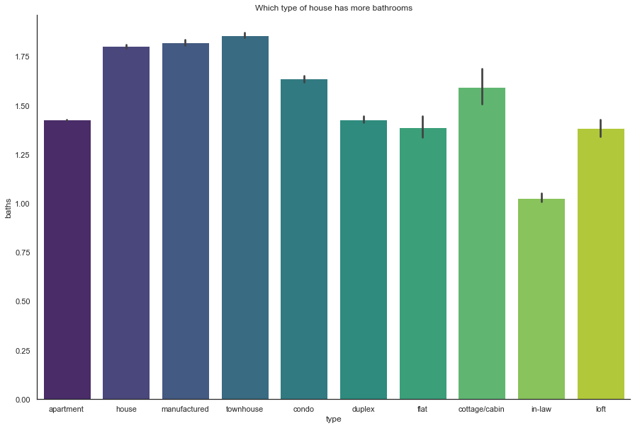

```python
sns.set_style("white")
fig, ax = plt.subplots(figsize=(15, 10))
sns.barplot(data["type"], data["baths"],ax=ax,palette="viridis")
plt.title('Which type of house has more bathrooms')
sns.despine()
```

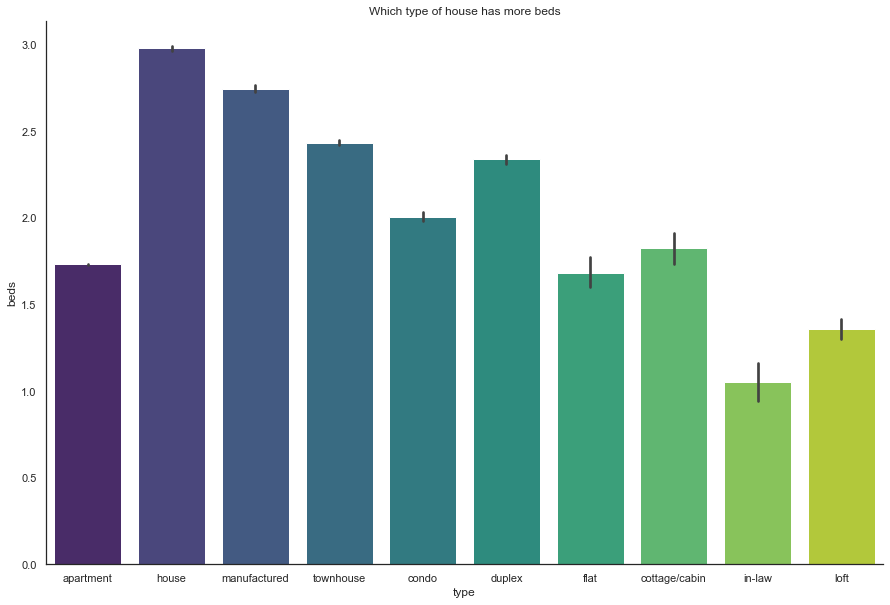

```python
sns.set_style("white")
fig, ax = plt.subplots(figsize=(15, 10))
sns.barplot(data["type"], data["beds"],ax=ax, palette="viridis")
sns.despine()
plt.title('Which type of house has more beds')
```

# • Data Processing

```python
from sklearn.preprocessing import LabelEncoder
label = LabelEncoder()
```

```python
data.info()
```

```
<class 'pandas.core.frame.DataFrame'>
RangeIndex: 259319 entries, 0 to 259318
Data columns (total 18 columns):
 #   Column                   Non-Null Count   Dtype
---  ------                   --------------   -----
 0   region                   259319 non-null  object
 1   price                    259319 non-null  int64
 2   type                     259319 non-null  object
 3   sqfeet                   259319 non-null  int64
 4   beds                     259319 non-null  int64
 5   baths                    259319 non-null  float64
 6   cats_allowed             259319 non-null  int64
 7   dogs_allowed             259319 non-null  int64
 8   smoking_allowed          259319 non-null  int64
 9   wheelchair_access        259319 non-null  int64
 10  electric_vehicle_charge  259319 non-null  int64
 11  comes_furnished          259319 non-null  int64
 12  laundry_options          259319 non-null  object
 13  parking_options          259319 non-null  object
 14  lat                      259319 non-null  float64
 15  long                     259319 non-null  float64
 16  state                    259319 non-null  object
 17  geometry                 259319 non-null  geometry
dtypes: float64(3), geometry(1), int64(9), object(5)
memory usage: 35.6+ MB
```

```python
data["region"]=label.fit_transform(data["region"])
data["type"]=label.fit_transform(data["type"])
data["laundry_options"]=label.fit_transform(data["laundry_options"])
data["parking_options"]=label.fit_transform(data["parking_options"])
data["state"]=label.fit_transform(data["state"])
```

```python
data.head()
```

|  | region | price | type | sqfeet | beds | baths | cats_allowed | dogs_allowed | smoking_allowed | wheelchair_access | electric_vehicle_charge | comes_furnished | laundry_options | parking_options | lat | long | state | geometry |
| --- | --- | --- | --- | --- | --- | --- | --- | --- | --- | --- | --- | --- | --- | --- | --- | --- | --- | --- |
| 0 | 21 | 1195 | 0 | 1908 | 3 | 2.0 | 1 | 1 | 1 | 0 | 0 | 0 | 1 | 5 | 33.4226 | -86.7065 | 1 | POINT (-86.70650 33.42260) |
| 1 | 21 | 1120 | 0 | 1319 | 3 | 2.0 | 1 | 1 | 1 | 0 | 0 | 0 | 1 | 4 | 33.3755 | -86.8045 | 1 | POINT (-86.80450 33.37550) |
| 2 | 21 | 825 | 0 | 1133 | 1 | 1.5 | 1 | 1 | 1 | 0 | 0 | 0 | 1 | 5 | 33.4226 | -86.7065 | 1 | POINT (-86.70650 33.42260) |
| 3 | 21 | 800 | 0 | 927 | 1 | 1.0 | 1 | 1 | 1 | 0 | 0 | 0 | 1 | 5 | 33.4226 | -86.7065 | 1 | POINT (-86.70650 33.42260) |
| 4 | 21 | 785 | 0 | 1047 | 2 | 1.0 | 1 | 1 | 1 | 0 | 0 | 0 | 1 | 5 | 33.4226 | -86.7065 | 1 | POINT (-86.70650 33.42260) |

##### All of our data is transformed to a numerical format.

```python
data.drop(columns = ['geometry'], inplace = True)
```

##### Because dogs allowed and cats allowed have such a strong co-relation, so can remove one and rename the field to pets allowed.

```python
data.drop(columns = ['cats_allowed'], inplace = True)
data.rename(columns = {'dogs_allowed' : 'pets_allowed'}, inplace = True)
data.head()
```

|  | region | price | type | sqfeet | beds | baths | pets_allowed | smoking_allowed | wheelchair_access | electric_vehicle_charge | comes_furnished | laundry_options | parking_options | lat | long | state |
| --- | --- | --- | --- | --- | --- | --- | --- | --- | --- | --- | --- | --- | --- | --- | --- | --- |
| 0 | 21 | 1195 | 0 | 1908 | 3 | 2.0 | 1 | 1 | 0 | 0 | 0 | 1 | 5 | 33.4226 | -86.7065 | 1 |
| 1 | 21 | 1120 | 0 | 1319 | 3 | 2.0 | 1 | 1 | 0 | 0 | 0 | 1 | 4 | 33.3755 | -86.8045 | 1 |
| 2 | 21 | 825 | 0 | 1133 | 1 | 1.5 | 1 | 1 | 0 | 0 | 0 | 1 | 5 | 33.4226 | -86.7065 | 1 |
| 3 | 21 | 800 | 0 | 927 | 1 | 1.0 | 1 | 1 | 0 | 0 | 0 | 1 | 5 | 33.4226 | -86.7065 | 1 |
| 4 | 21 | 785 | 0 | 1047 | 2 | 1.0 | 1 | 1 | 0 | 0 | 0 | 1 | 5 | 33.4226 | -86.7065 | 1 |

```python
data.describe().T
```

|  | count | mean | std | min | 25% | 50% | 75% | max |
| --- | --- | --- | --- | --- | --- | --- | --- | --- |
| region | 259319.0 | 139.562651 | 88.461359 | 0.0000 | 59.0000 | 139.0000 | 217.0000 | 297.0000 |
| price | 259319.0 | 1194.645518 | 557.423583 | 0.0000 | 815.0000 | 1053.0000 | 1435.0000 | 4000.0000 |
| type | 259319.0 | 0.954770 | 2.324722 | 0.0000 | 0.0000 | 0.0000 | 0.0000 | 9.0000 |
| sqfeet | 259319.0 | 985.955264 | 351.330701 | 0.0000 | 750.0000 | 950.0000 | 1150.0000 | 3000.0000 |
| beds | 259319.0 | 1.887582 | 0.868298 | 0.0000 | 1.0000 | 2.0000 | 2.0000 | 8.0000 |
| baths | 259319.0 | 1.483763 | 0.565016 | 1.0000 | 1.0000 | 1.0000 | 2.0000 | 6.0000 |
| pets_allowed | 259319.0 | 0.698059 | 0.459101 | 0.0000 | 0.0000 | 1.0000 | 1.0000 | 1.0000 |
| smoking_allowed | 259319.0 | 0.734940 | 0.441366 | 0.0000 | 0.0000 | 1.0000 | 1.0000 | 1.0000 |
| wheelchair_access | 259319.0 | 0.078872 | 0.269539 | 0.0000 | 0.0000 | 0.0000 | 0.0000 | 1.0000 |
| electric_vehicle_charge | 259319.0 | 0.014025 | 0.117595 | 0.0000 | 0.0000 | 0.0000 | 0.0000 | 1.0000 |
| comes_furnished | 259319.0 | 0.046599 | 0.210779 | 0.0000 | 0.0000 | 0.0000 | 0.0000 | 1.0000 |
| laundry_options | 259319.0 | 2.920804 | 1.447557 | 0.0000 | 1.0000 | 4.0000 | 4.0000 | 4.0000 |
| parking_options | 259319.0 | 3.206846 | 1.484986 | 0.0000 | 2.0000 | 4.0000 | 4.0000 | 6.0000 |
| lat | 259319.0 | 37.219989 | 5.659076 | -40.2666 | 33.5059 | 37.9863 | 41.1901 | 102.0360 |
| long | 259319.0 | -92.298855 | 17.300744 | -163.8940 | -103.6240 | -86.4231 | -81.2846 | 94.1561 |
| state | 259319.0 | 15.402901 | 10.001982 | 0.0000 | 7.0000 | 14.0000 | 23.0000 | 37.0000 |

# • Data Prediction and Modeling

```python
X = data.drop(columns = ['price'])
y = data.price
```

```python
from sklearn.model_selection import train_test_split
X_train,X_test,y_train,y_test = train_test_split(X, y, test_size = 0.20,random_state = 1)
```

```python
from sklearn.tree import DecisionTreeRegressor
from sklearn.ensemble import RandomForestRegressor
from sklearn.linear_model import LinearRegression
from sklearn import neighbors
from sklearn.metrics import accuracy_score
from sklearn import metrics
from sklearn.ensemble import GradientBoostingRegressor
```

#### 1.Random Forest Regressor

```python
acc = np.array([])
randomForest = RandomForestRegressor()
randomForest.fit(X_train,y_train)
randomForest.predict(X_test)
x=randomForest.score(X_test, y_test)
print(x)
acc = np.append(acc, x)
```

```
0.8966836560555288
```

#### 2.Decision Tree Regressor

```python
decisionTree = DecisionTreeRegressor()
decisionTree.fit(X_train,y_train)
decisionTree.predict(X_test)
x=decisionTree.score(X_test, y_test)
print(x)
acc = np.append(acc, x)
```

```
0.816347966733835
```

#### 3.Linear Regression

```python
linearRegressor = LinearRegression()
linearRegressor.fit(X_train,y_train)
linearRegressor.predict(X_test)
x=linearRegressor.score(X_test, y_test)
print(x)
acc = np.append(acc, x)
```

```
0.24567602753126283
```

#### 4.KNN Regressor

with n_neighbors=1

```python
KNN = neighbors.KNeighborsRegressor(n_neighbors = 1)
KNN.fit(X_train,y_train)
KNN.predict(X_test)
x=KNN.score(X_test, y_test)
print(x)
```

```
0.7362307181733981
```

with n_neighbors=2

```python
KNN = neighbors.KNeighborsRegressor(n_neighbors = 2)
KNN.fit(X_train,y_train)
KNN.predict(X_test)
x=KNN.score(X_test, y_test)
print(x)
acc = np.append(acc, x)
```

```
0.765593306793707
```

with n_neighbors=4

```python
KNN = neighbors.KNeighborsRegressor(n_neighbors = 4)
KNN.fit(X_train,y_train)
KNN.predict(X_test)
x=KNN.score(X_test, y_test)
print(x)
```

```
0.7644116263364554
```

with n_neighbors=5

```python
KNN = neighbors.KNeighborsRegressor(n_neighbors = 5)
KNN.fit(X_train,y_train)
KNN.predict(X_test)
x=KNN.score(X_test, y_test)
print(x)
```

```
0.7585553796697284
```

with n_neighbors=6

```python
KNN = neighbors.KNeighborsRegressor(n_neighbors = 6)
KNN.fit(X_train,y_train)
KNN.predict(X_test)
x=KNN.score(X_test, y_test)
print(x)
```

```
0.7527925099926892
```

with n_neighbors=8

```python
KNN = neighbors.KNeighborsRegressor(n_neighbors = 8)
KNN.fit(X_train,y_train)
KNN.predict(X_test)
x=KNN.score(X_test, y_test)
print(x)
```

```
0.7410984855693326
```

#### Model Accuracies

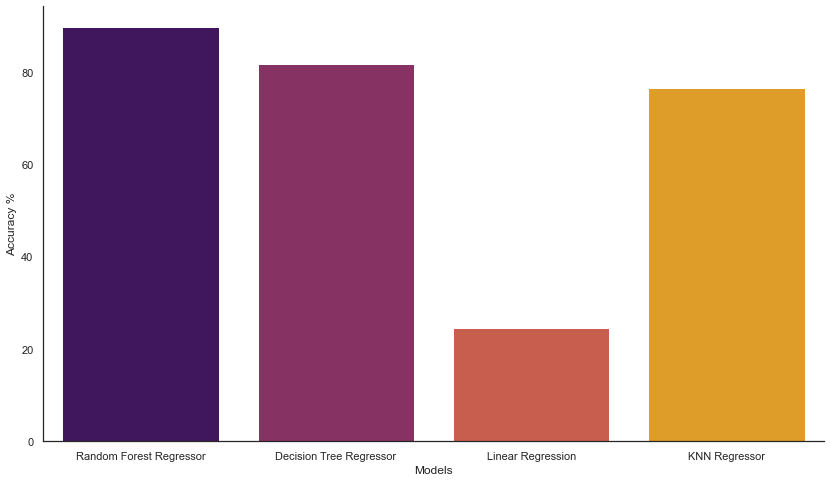

```python
models = ['Random Forest Regressor', 'Decision Tree Regressor', 'Linear Regression', 'KNN Regressor']
accuracy = acc
fig, ax = plt.subplots(figsize=(14, 8))
sns.barplot(models, accuracy*100,ax=ax, palette="inferno")
plt.xlabel('Models')
plt.ylabel('Accuracy %')
sns.despine()
```

# • Conclusion

#### We've completed all the essential data processing and calculations, and Random Forest Regressor has the greatest accuracy score for Rent Prediction of all the algorithms employed.